# R Notebook

EJERCICO FINAL MODULO 5 .

## Sara Sirviente

### DATA SCIENCE JOB SALARIES

El objetivo de este ejercico es analizar y evaluar el salario de un científico de datos en los últimos 3 años.

El conjunto de datos que se escoge para este ejercicio se obntiene a partir de Kaggle (https://www.kaggle.com/datasets/ruchi798/data-science-job-salaries). E

El dataset proviene de los resultados de la agregación de datos por ai-jobs.net ( plataforma que ofrece a los solicitantes aplicar a trabajos de AI/ML y Big Data en todo el mundo). Se obtuvo de proporcionar formularios a todos los que tienen trabajos de AI/ML y Big Data para completar los datos salariales de manera transparente.

*work_year = El año en que se pagó el salario.* experience_level = El nivel de experiencia en el trabajo durante el año con los siguientes valores posibles. ES = Nivel de entrada / Junior MI = Nivel medio / Intermedio SE = Nivel superior / Experto EX = Nivel ejecutivo / Director *empleo_tipo = El tipo de empleo para el rol. PT = Tiempo parcial FT = tiempo completo CT = Contrato FL = Independiente* job_title = El rol en el que trabajó durante el año. *salario = cuantía total del salario bruto pagado.* salario_currency = La moneda del salario pagado como código de moneda ISO 4217. *salario_in_usd = El salario en USD (tasa de cambio dividida por la tasa promedio de USD para el año respectivo a través de fxdata.foorilla.com).* employee_residence = País principal de residencia del empleado durante el año laboral como código de país ISO 3166. *remote_ratio = La cantidad total de trabajo realizado de forma remota, los valores posibles son los siguientes. 0 = Sin trabajo remoto (menos del 20%) 50 = Parcialmente remoto 100 = Totalmente remoto (más del 80 %)* company_location = El país de la oficina principal del empleador o sucursal contratante como un código de país ISO 3166. *company_size = Número promedio de personas que trabajaron para la empresa durante el año S = menos de 50 empleados (pequeño) M = 50 a 250 empleados (medio) L = más de 250 empleados (grande)

Primero cargamos las librerías que usaremos:

```r
library(dplyr)
library(ggplot2)
library(caret)
library(corrplot)
library(MASS)
library(fastDummies)
```

```r
#cargamos el archivo
df <- read.csv("ds_salaries.csv", stringsAsFactors = T)
head(df,5)
```

|  | X | work_year | experience_level | employment_type | job_title | salary | salary_currency | salary_in_usd | employee_residence | remote_ratio | company_location | company_size |
| --- | --- | --- | --- | --- | --- | --- | --- | --- | --- | --- | --- | --- |
| 1 | 0 | 2020 | MI | FT | Data Scientist | 70000 | EUR | 79833 | DE | 0 | DE | L |
| 2 | 1 | 2020 | SE | FT | Machine Learning Scientist | 260000 | USD | 260000 | JP | 0 | JP | S |
| 3 | 2 | 2020 | SE | FT | Big Data Engineer | 85000 | GBP | 109024 | GB | 50 | GB | M |
| 4 | 3 | 2020 | MI | FT | Product Data Analyst | 20000 | USD | 20000 | HN | 0 | HN | S |
| 5 | 4 | 2020 | SE | FT | Machine Learning Engineer | 150000 | USD | 150000 | US | 50 | US | L |

```r
NA
```

```r
summary (df)
```

[output not shown]

Queremos analizar el salario de un data science por ello podemos quedarnos unicamente con el salario en USD, por lo que eliminamos el tipo de moneda. el ratio y el salario pagado. También vamos a quitar la columna 1, que solo enumera las filas, ya que no aporta ningún tipo de información

```r
df$salary <- NULL
df$salary_currency<- NULL
df$X<- NULL
df$remote_ratio<- NULL

summary(df)
```

```
   work_year    experience_level employment_type                     job_title   salary_in_usd    employee_residence company_location company_size
 Min.   :2020   EN: 88           CT:  5          Data Scientist           :143   Min.   :  2859   US     :332        US     :355      L:198
 1st Qu.:2021   EX: 26           FL:  4          Data Engineer            :132   1st Qu.: 62726   GB     : 44        GB     : 47      M:326
 Median :2022   MI:213           FT:588          Data Analyst             : 97   Median :101570   IN     : 30        CA     : 30      S: 83
 Mean   :2021   SE:280           PT: 10          Machine Learning Engineer: 41   Mean   :112298   CA     : 29        DE     : 28
 3rd Qu.:2022                                    Research Scientist       : 16   3rd Qu.:150000   DE     : 25        IN     : 24
 Max.   :2022                                    Data Science Manager     : 12   Max.   :600000   FR     : 18        FR     : 15
                                                 (Other)                  :166                    (Other):129        (Other):108
```

Se ve si existen nulos (nan values)

```r
sapply(df, function(x) sum(is.na(x)))
```

```
         work_year   experience_level    employment_type          job_title      salary_in_usd employee_residence   company_location       company_size
                 0                  0                  0                  0                  0                  0                  0                  0
```

No hay ningun valor nulo, estupendo. Porcedemos a realizar un EDA

```r
str(df)
```

```
'data.frame':   607 obs. of  8 variables:
 $ work_year         : int  2020 2020 2020 2020 2020 2020 2020 2020 2020 2020 ...
 $ experience_level  : Factor w/ 4 levels "EN","EX","MI",..: 3 4 4 3 4 1 4 3 3 4 ...
 $ employment_type   : Factor w/ 4 levels "CT","FL","FT",..: 3 3 3 3 3 3 3 3 3 3 ...
 $ job_title         : Factor w/ 50 levels "3D Computer Vision Researcher",..: 23 41 8 48 38 13 35 23 9 34 ...
 $ salary_in_usd     : int  79833 260000 109024 20000 150000 72000 190000 35735 135000 125000 ...
 $ employee_residence: Factor w/ 57 levels "AE","AR","AT",..: 15 33 21 24 56 56 56 26 56 42 ...
 $ company_location  : Factor w/ 50 levels "AE","AS","AT",..: 13 30 19 21 49 49 49 23 49 39 ...
 $ company_size      : Factor w/ 3 levels "L","M","S": 1 3 2 3 1 1 3 1 1 3 ...
```

vemos que hay variables categóricas y numéricas, llama la atención que hay 50 niveles de tipos de trabajo y 57 paises. Esto sugiere que se podría agrupar por trabajos parecidos ( Analistas de datos, ingenieros, ML,etc), por continentes, etc. De momento vamos a observar los valores unicos y el numero de individuos de los tipos de empleo.

```r
unique(df$job_title)
```

```
 [1] Data Scientist                           Machine Learning Scientist               Big Data Engineer
 [4] Product Data Analyst                     Machine Learning Engineer                Data Analyst
 [7] Lead Data Scientist                      Business Data Analyst                    Lead Data Engineer
[10] Lead Data Analyst                        Data Engineer                            Data Science Consultant
[13] BI Data Analyst                          Director of Data Science                 Research Scientist
[16] Machine Learning Manager                 Data Engineering Manager                 Machine Learning Infrastructure Engineer
[19] ML Engineer                              AI Scientist                             Computer Vision Engineer
[22] Principal Data Scientist                 Data Science Manager                     Head of Data
[25] 3D Computer Vision Researcher            Data Analytics Engineer                  Applied Data Scientist
[28] Marketing Data Analyst                   Cloud Data Engineer                      Financial Data Analyst
[31] Computer Vision Software Engineer        Director of Data Engineering             Data Science Engineer
[34] Principal Data Engineer                  Machine Learning Developer               Applied Machine Learning Scientist
[37] Data Analytics Manager                   Head of Data Science                     Data Specialist
[40] Data Architect                           Finance Data Analyst                     Principal Data Analyst
[43] Big Data Architect                       Staff Data Scientist                     Analytics Engineer
[46] ETL Developer                            Head of Machine Learning                 NLP Engineer
[49] Lead Machine Learning Engineer           Data Analytics Lead
50 Levels: 3D Computer Vision Researcher AI Scientist Analytics Engineer Applied Data Scientist Applied Machine Learning Scientist ... Staff Data Scientist
```

```r
table(df$job_title)
```

```
           3D Computer Vision Researcher                             AI Scientist                       Analytics Engineer
                                       1                                        7                                        4
                  Applied Data Scientist       Applied Machine Learning Scientist                          BI Data Analyst
                                       5                                        4                                        6
                      Big Data Architect                        Big Data Engineer                    Business Data Analyst
                                       1                                        8                                        5
                     Cloud Data Engineer                 Computer Vision Engineer        Computer Vision Software Engineer
                                       2                                        6                                        3
                            Data Analyst                  Data Analytics Engineer                      Data Analytics Lead
                                      97                                        4                                        1
                  Data Analytics Manager                           Data Architect                            Data Engineer
                                       7                                       11                                      132
                Data Engineering Manager                  Data Science Consultant                    Data Science Engineer
                                       5                                        7                                        3
                    Data Science Manager                           Data Scientist                          Data Specialist
                                      12                                      143                                        1
            Director of Data Engineering                 Director of Data Science                            ETL Developer
                                       2                                        7                                        2
                    Finance Data Analyst                   Financial Data Analyst                             Head of Data
                                       1                                        2                                        5
                    Head of Data Science                 Head of Machine Learning                        Lead Data Analyst
                                       4                                        1                                        3
                      Lead Data Engineer                      Lead Data Scientist           Lead Machine Learning Engineer
                                       6                                        3                                        1
              Machine Learning Developer                Machine Learning Engineer Machine Learning Infrastructure Engineer
                                       3                                       41                                        3
                Machine Learning Manager               Machine Learning Scientist                   Marketing Data Analyst
                                       1                                        8                                        1
                             ML Engineer                             NLP Engineer                   Principal Data Analyst
                                       6                                        1                                        2
                 Principal Data Engineer                 Principal Data Scientist                     Product Data Analyst
                                       3                                        7                                        2
                      Research Scientist                     Staff Data Scientist
                                      16                                        1
```

una vez se ha realizado el análisis exploratorio de los datos, se procede a aplicar un analisis estadistico para sacar conclusiones del dataset. Vamos a realizar primero unanalisis cualitativo dónde representaremos todas las variabes. Si son categoricas; diagrama de barras y si son numericas; histograma

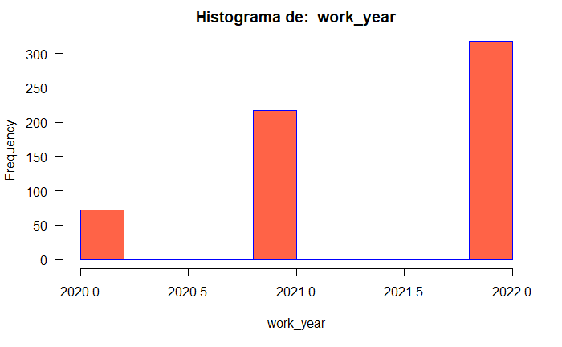

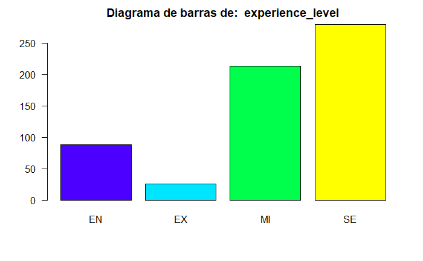

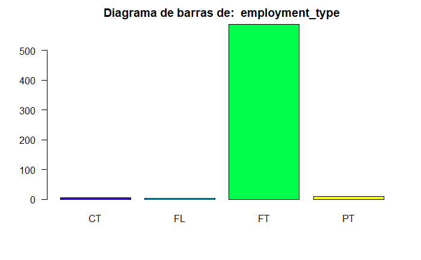

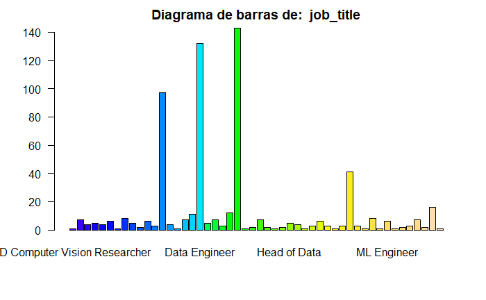

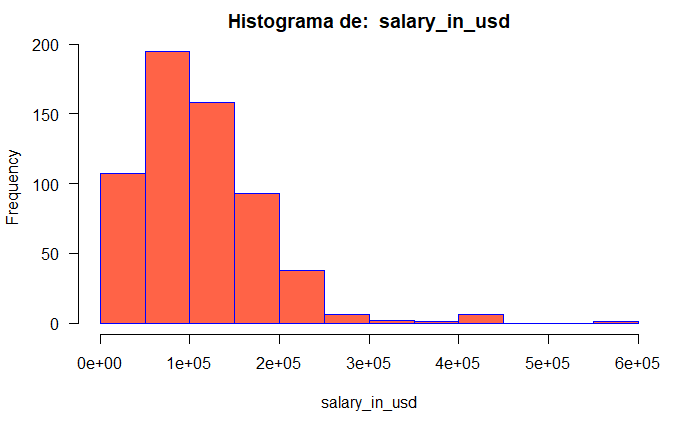

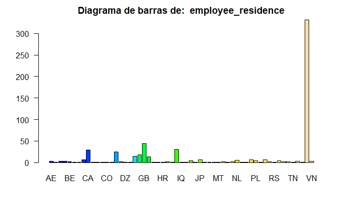

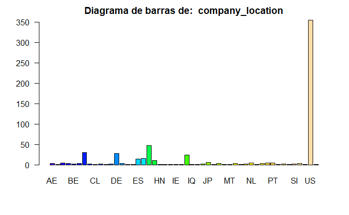

```r
for (columna in 1:ncol(df)){
  if (class(df[,columna]) == "factor"){
    # Por defecto se mostrará un gráfico de barras.
    plot(df[,columna],
         col = topo.colors(length(levels(df[,columna]))),
         las = 1,
         main = paste("Diagrama de barras de: ", colnames(df[columna])))
  } else {
    # Para las variables numéricas, histograma.
    hist(df[, columna],
         border = "blue",
         col = "tomato",
         las = 1,
         main = paste("Histograma de: ", colnames(df[columna])),
         xlab  = colnames(df[columna]))
  }
}
```

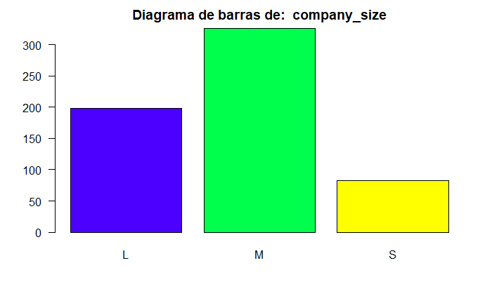

```r
NA
```

A partir de estas visualizaciones podemos empezar a sacar resultados preliminares:

*work_year*: El año que mayor frecuencia tiene es 2022. Es decir, mas de la mitad de los datos de salario pertenecena 2022 *experience_level*: Se ve cómo la mayoria de los ecuestados contaban con bastante experiencia eran expertos (SE), también resaltar que el menor numero de ellos eran directivos. *employment_type*: Casi todos ellos estaban presentaban un contrato con dedicación a tiempo completo. *company_location*: También que la mayoría de las compañías tenían su localización en USA. *company_size*: La mayoria de las compañías tenían ente 50 y 250 empleados.

Se procede a hacer un análisis más exhaustivo de los datos y a buscar si existe algúna relación entre las variables del mismo.

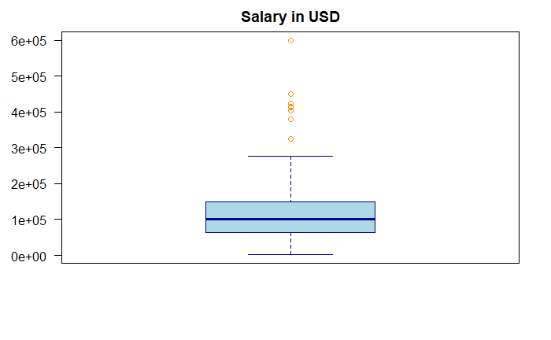

```r
boxplot(df$salary_in_usd,
        border = "darkblue",
        col = "lightblue",
        main = "Salary in USD",
        las = 1,
        outcol="darkorange")
```

Observando este diagrama de caja, se obtiene que la mayoría de los empleados tienen un sueldo de 100.000 USD, tener un salario más alto es bastante atípico sobretodo por encima de los 300.000 USD.

```r
#ahora se analiza la dependencia del salario con la experiencia de cada empleado
df$experience_level_new = factor(df$experience_level, levels=c('EN','MI','SE','EX'))
```

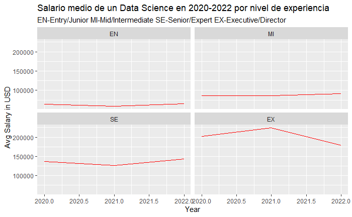

```r
ggplot(data = df) +
geom_line(mapping = aes(x = work_year, y = salary_in_usd), color = "red", stat = "summary", fun = "mean")+
labs(title="Salario medio de un Data Science en 2020-2022 por nivel de experiencia", x = "Year", y = "Avg Salary in USD", subtitle = "EN-Entry/Junior MI-Mid/Intermediate SE-Senior/Expert EX-Executive/Director")+
facet_wrap(~experience_level_new)
```

En el gráfico anterior se puede ver el cambio del salario medio en funcion del año y del nivel de experiencia, se observa un comportamiento practicamente lineal para los junior y para el nivel de experiecia intrmdio. Sin embargo para los senior, se aprecia un ligero aumento desde 2021 hasta 2022 y al contrario en los puestos de Ejecutivos

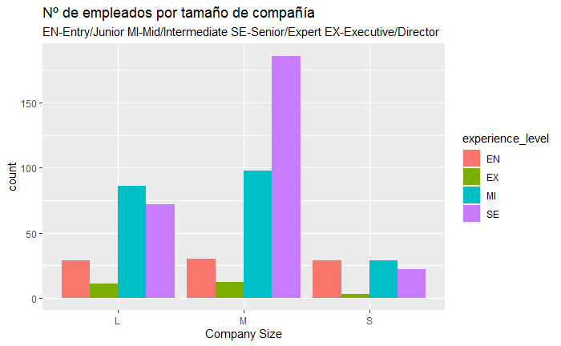

```r
ggplot(data = df) +
  geom_bar(mapping = aes(x= company_size,  fill = experience_level),
  stat = "count", position = "dodge")+
  labs(title = "Nº de empleados por tamaño de compañía", x = "Company Size",subtitle = "EN-Entry/Junior MI-Mid/Intermediate SE-Senior/Expert EX-Executive/Director")+
  guides(guide_legend(title = "experience_level"))
```

Las empresas de tamaño intermedio cuentan con más empleados cuyo nivel de experiencia es Senior. Las empresas pequeñas son las que cuentan con prácticamente el mismo número de empleados Junior e intermedios. Cómo se había ido percibiendo anteriormente, el menor numero de empleados para todos los tamños de empresa es el nivel de dirección.

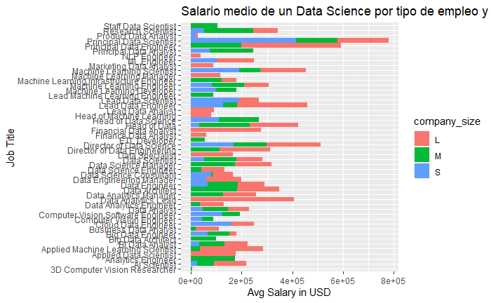

```r
ggplot(data=df) +
geom_bar(aes(x = job_title, y = salary_in_usd, fill = company_size), stat = "summary", fun = "mean") +
    coord_flip() +
      labs(title="Salario medio de un Data Science por tipo de empleo y tamaño de la compañía", x = "Job Title", y = "Avg Salary in USD")
```

Si comparamos el salario medio con el tipo de trabajo ( Job title) y a su vez vemos el tamaño de la empresa, podemos ver una brecha salarial entre los diferentes tipos de trabajo y el tamaño de la empresa. Llama la atención que de algunos jobs solo hay un tamaño de medida (ej: DATA ANALYTICS LEAD), esto puede generar confusiones, ya que los resultados estan sesgados. Si volvemos un poco más arriba dónde se sacó el numero de individuos de cada nivel de la variable job_title, podemos ver que solo hay uno con este tipo de trabajo y así ocurre con varios puestos a diferencia de otros como Research Scientist que tiene 16 personas. Esto genera que los salarios medios no sean representativos cuando sólo hay una persona.

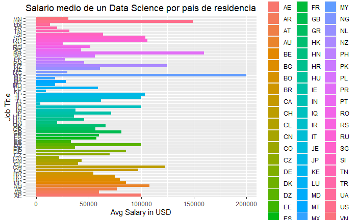

```r
ggplot(data=df) +
geom_bar(aes(x = employee_residence, y = salary_in_usd, fill = employee_residence), stat = "summary", fun = "mean") +
    coord_flip() +
      labs(title="Salario medio de un Data Science por pais de residencia", x = "Job Title", y = "Avg Salary in USD")
```

```r
df %>%
  count(employee_residence)
```

| employee_residence | n |
| --- | --- |
| AE | 3 |
| AR | 1 |
| AT | 3 |
| AU | 3 |
| BE | 2 |
| BG | 1 |
| BO | 1 |
| BR | 6 |
| CA | 29 |
| CH | 1 |

[output cut: 47 more lines]

Si analizamos el salario en funcion del pais de residencia, vemos que hay resultados que llaman la atención. Elsueldo más alto se alcanza por un empleado que vive en Malasia frente a los 332 individuos estudiados que residen en USA. Debido a esto, se decide continuar el análisis del salario de un científico de datos solo con los individuos que residen en USA.

```r
df2 <- filter(df, employee_residence == "US")
df2
```

| work_year | experience_level | employment_type | job_title | salary_in_usd | employee_residence | company_location | company_size | experience_level_new |
| --- | --- | --- | --- | --- | --- | --- | --- | --- |
| 2020 | SE | FT | Machine Learning Engineer | 150000 | US | US | L | SE |
| 2020 | EN | FT | Data Analyst | 72000 | US | US | L | EN |
| 2020 | SE | FT | Lead Data Scientist | 190000 | US | US | S | SE |
| 2020 | MI | FT | Business Data Analyst | 135000 | US | US | L | MI |
| 2020 | MI | FT | Lead Data Analyst | 87000 | US | US | L | MI |
| 2020 | MI | FT | Data Analyst | 85000 | US | US | L | MI |
| 2020 | MI | FT | BI Data Analyst | 98000 | US | US | M | MI |
| 2020 | EX | FT | Director of Data Science | 325000 | US | US | L | EX |
| 2020 | EN | CT | Business Data Analyst | 100000 | US | US | L | EN |
| 2020 | EN | FT | Big Data Engineer | 70000 | US | US | L | EN |

[output cut: 322 more lines]

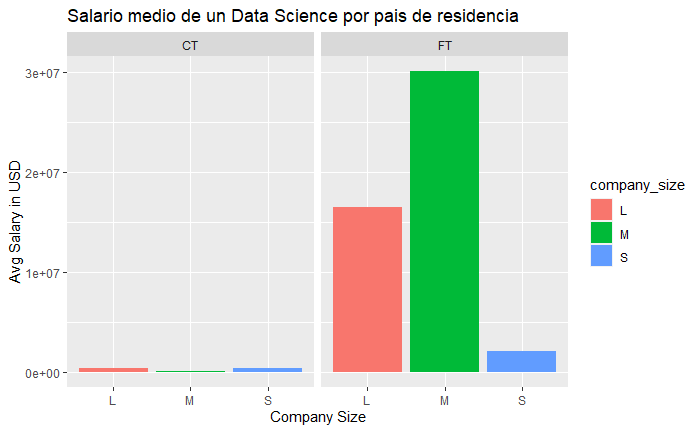

```r
salary_per_employment_type_company_size <- df2 %>%
                                  group_by(company_size,employment_type)
ggplot(data = salary_per_employment_type_company_size,) + geom_col(mapping = aes(x = company_size,y = salary_in_usd, fill= company_size)) + facet_wrap(~employment_type)+labs(title="Salario medio de un Data Science por pais de residencia", x = "Company Size", y = "Avg Salary in USD")
```

Vemos que hay sueldos que superanlos 300.000 USD/año, vamos a ver que tipo de empleo presentan estos sueldos y el sueldo de una persona con poca experiencia ( EN)

```r
filter(df2, df2$salary_in_usd >= 300000)
```

| work_year | experience_level | employment_type | job_title | salary_in_usd | employee_residence | company_location | company_size | experience_level_new |
| --- | --- | --- | --- | --- | --- | --- | --- | --- |
| 2020 | EX | FT | Director of Data Science | 325000 | US | US | L | EX |
| 2020 | MI | FT | Research Scientist | 450000 | US | US | M | MI |
| 2020 | SE | FT | Data Scientist | 412000 | US | US | L | SE |
| 2021 | MI | FT | Financial Data Analyst | 450000 | US | US | L | MI |
| 2021 | MI | FT | Applied Machine Learning Scientist | 423000 | US | US | L | MI |
| 2021 | EX | CT | Principal Data Scientist | 416000 | US | US | S | EX |
| 2021 | EX | FT | Principal Data Engineer | 600000 | US | US | L | EX |
| 2022 | EX | FT | Data Engineer | 324000 | US | US | M | EX |
| 2022 | SE | FT | Applied Data Scientist | 380000 | US | US | L | SE |
| 2022 | SE | FT | Data Analytics Lead | 405000 | US | US | L | SE |

```r
filter(df2, df2$experience_level == "EN")
```

| work_year | experience_level | employment_type | job_title | salary_in_usd | employee_residence | company_location | company_size | experience_level_new |
| --- | --- | --- | --- | --- | --- | --- | --- | --- |
| 2020 | EN | FT | Data Analyst | 72000 | US | US | L | EN |
| 2020 | EN | CT | Business Data Analyst | 100000 | US | US | L | EN |
| 2020 | EN | FT | Big Data Engineer | 70000 | US | US | L | EN |
| 2020 | EN | FT | Machine Learning Engineer | 250000 | US | US | L | EN |
| 2020 | EN | FT | Machine Learning Engineer | 138000 | US | US | S | EN |
| 2020 | EN | FT | Data Analyst | 91000 | US | US | L | EN |
| 2020 | EN | FT | Data Scientist | 105000 | US | US | S | EN |
| 2021 | EN | FT | Data Analyst | 80000 | US | US | M | EN |
| 2021 | EN | FT | Computer Vision Software Engineer | 70000 | US | US | M | EN |
| 2021 | EN | FT | Machine Learning Scientist | 225000 | US | US | L | EN |

[output cut: 19 more lines]

```r
NA
```

Si analizamos el sueldo para las personas que no tienen mucha experiencia (Junior) vemos que en los tipos de trabajo que tienen los sueldos más altos son los relacionados con el Machine learning en empresas grandes. En promedio el sueldo para una persona con poca experiencia es <=100000.

##### Una vez exploradas y observados algunos de los comportamientos de las variables se procede a realizar un analisis estadístico más exhaustivo con la variable sin filtrar por US.

```r
with(df,
  case_when(
    salary_in_usd <= "150000"  ~ 0,  # Doble nacionalidad
    salary_in_usd >= "150000"  ~ 1,  # Española

  )
) -> df$salary_binaria
df
```

| work_year | experience_level | employment_type | job_title | salary_in_usd | employee_residence | company_location | company_size | experience_level_new | salary_binaria |
| --- | --- | --- | --- | --- | --- | --- | --- | --- | --- |
| 2020 | MI | FT | Data Scientist | 79833 | DE | DE | L | MI | 1 |
| 2020 | SE | FT | Machine Learning Scientist | 260000 | JP | JP | S | SE | 1 |
| 2020 | SE | FT | Big Data Engineer | 109024 | GB | GB | M | SE | 0 |
| 2020 | MI | FT | Product Data Analyst | 20000 | HN | HN | S | MI | 1 |
| 2020 | SE | FT | Machine Learning Engineer | 150000 | US | US | L | SE | 0 |
| 2020 | EN | FT | Data Analyst | 72000 | US | US | L | EN | 1 |
| 2020 | SE | FT | Lead Data Scientist | 190000 | US | US | S | SE | 1 |
| 2020 | MI | FT | Data Scientist | 35735 | HU | HU | L | MI | 1 |
| 2020 | MI | FT | Business Data Analyst | 135000 | US | US | L | MI | 0 |
| 2020 | SE | FT | Lead Data Engineer | 125000 | NZ | NZ | S | SE | 0 |

[output cut: 597 more lines]

### Test de normalidad para las variables numéricas.

```r
numeric.values <- df %>% dplyr::select(work_year,salary_in_usd)

sapply(sample_n(numeric.values, 607), function(x) round(shapiro.test(x)$p.value,2))
```

```
    work_year salary_in_usd
            0             0
```

Si la H0 (p_valor<=0.05) sería que la variable no proviene de una distribución normal y H1 (>0.05) que si. Se obtiene que ninguna variable numérica proviene de una distribución normal.

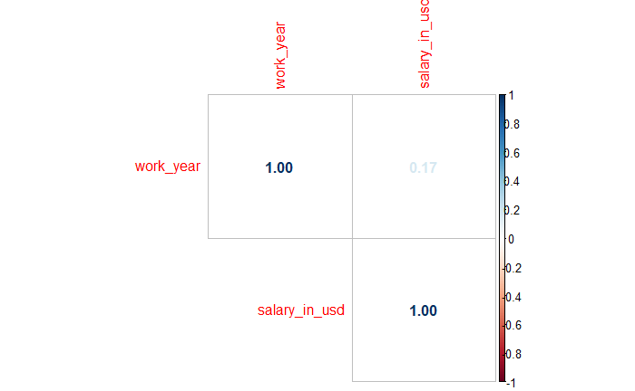

```r
corrplot(cor(numeric.values), method = "number", type="upper")
```

La matriz de correlaciones presenta correlaciones bajas entre las variables numéricas.

Creamos un dataframe nuevo eliminando varias columnas, salar_in_usd ( ya que tenemos la columna que creamos salary_binaria), job_title y employee_residence ( estas dops las omitimos porque generan confusión al ser muy sesgadas) para no generar errores en el estudio.

```r
df
```

| work_year | experience_level | employment_type | job_title | salary_in_usd | employee_residence | company_location | company_size | experience_level_new | salary_binaria |
| --- | --- | --- | --- | --- | --- | --- | --- | --- | --- |
| 2020 | MI | FT | Data Scientist | 79833 | DE | DE | L | MI | 1 |
| 2020 | SE | FT | Machine Learning Scientist | 260000 | JP | JP | S | SE | 1 |
| 2020 | SE | FT | Big Data Engineer | 109024 | GB | GB | M | SE | 0 |
| 2020 | MI | FT | Product Data Analyst | 20000 | HN | HN | S | MI | 1 |
| 2020 | SE | FT | Machine Learning Engineer | 150000 | US | US | L | SE | 0 |
| 2020 | EN | FT | Data Analyst | 72000 | US | US | L | EN | 1 |
| 2020 | SE | FT | Lead Data Scientist | 190000 | US | US | S | SE | 1 |
| 2020 | MI | FT | Data Scientist | 35735 | HU | HU | L | MI | 1 |
| 2020 | MI | FT | Business Data Analyst | 135000 | US | US | L | MI | 0 |
| 2020 | SE | FT | Lead Data Engineer | 125000 | NZ | NZ | S | SE | 0 |

[output cut: 597 more lines]

```r
df_final <- df[c("work_year","experience_level","employment_type","salary_binaria","company_location","company_size")]
df_final
```

| work_year | experience_level | employment_type | salary_binaria | company_location | company_size |
| --- | --- | --- | --- | --- | --- |
| 2020 | MI | FT | 1 | DE | L |
| 2020 | SE | FT | 1 | JP | S |
| 2020 | SE | FT | 0 | GB | M |
| 2020 | MI | FT | 1 | HN | S |
| 2020 | SE | FT | 0 | US | L |
| 2020 | EN | FT | 1 | US | L |
| 2020 | SE | FT | 1 | US | S |
| 2020 | MI | FT | 1 | HU | L |
| 2020 | MI | FT | 0 | US | L |
| 2020 | SE | FT | 0 | NZ | S |

[output cut: 597 more lines]